# AAB_test_mobile_app

## Анализ пользовательского поведения в мобильном приложении

Оглавление :

1. Шаг 1. Загрузка данных и подготовка их к анализу
1. Шаг 2. Изучение данных
1. Шаг 3. Изучение воронки событий
1. Шаг 4. Изучение результатов эксперимента

### Шаг 1. Загрузка данных и подготовка их к анализу

```python
import pandas as pd
import datetime as dt
import matplotlib.pyplot as plt
from plotly import graph_objects as go
import math as mth
from scipy import stats as st
import warnings
warnings.filterwarnings("ignore")
```

```python
data = pd.read_csv('projects/datasets/logs_exp.csv', delimiter='\t')
```

```python
data.sample(10)
```

|  | EventName | DeviceIDHash | EventTimestamp | ExpId |
| --- | --- | --- | --- | --- |
| 238282 | PaymentScreenSuccessful | 4541002331784686531 | 1565197607 | 247 |
| 240113 | PaymentScreenSuccessful | 2207627660352986049 | 1565201427 | 247 |
| 232634 | PaymentScreenSuccessful | 7395245891263521254 | 1565189733 | 248 |
| 217772 | OffersScreenAppear | 3739968493066894778 | 1565160593 | 248 |
| 14895 | MainScreenAppear | 7661139663123154470 | 1564656508 | 247 |
| 18545 | CartScreenAppear | 197027893265565660 | 1564661987 | 246 |
| 136047 | MainScreenAppear | 3530408535473465435 | 1564942058 | 247 |
| 56284 | PaymentScreenSuccessful | 1152409031019339050 | 1564748860 | 247 |
| 213422 | MainScreenAppear | 1775630733957320125 | 1565144658 | 246 |
| 179127 | OffersScreenAppear | 4803676806948296477 | 1565065956 | 248 |

Заменим названия столбцов:

```python
data.rename(columns={'EventName': 'event_name', 'DeviceIDHash': 'device_id',
                     'EventTimestamp': 'timestamp', 'ExpId': 'exp_group'}, inplace=True)
```

```python
data.head()
```

|  | event_name | device_id | timestamp | exp_group |
| --- | --- | --- | --- | --- |
| 0 | MainScreenAppear | 4575588528974610257 | 1564029816 | 246 |
| 1 | MainScreenAppear | 7416695313311560658 | 1564053102 | 246 |
| 2 | PaymentScreenSuccessful | 3518123091307005509 | 1564054127 | 248 |
| 3 | CartScreenAppear | 3518123091307005509 | 1564054127 | 248 |
| 4 | PaymentScreenSuccessful | 6217807653094995999 | 1564055322 | 248 |

```python
data.info()
```

```
<class 'pandas.core.frame.DataFrame'>
RangeIndex: 244126 entries, 0 to 244125
Data columns (total 4 columns):
 #   Column      Non-Null Count   Dtype
---  ------      --------------   -----
 0   event_name  244126 non-null  object
 1   device_id   244126 non-null  int64
 2   timestamp   244126 non-null  int64
 3   exp_group   244126 non-null  int64
dtypes: int64(3), object(1)
memory usage: 7.5+ MB
```

```python
data['event_date'] = pd.to_datetime(data['timestamp'], unit='s')
```

```python
data['event_day'] = data['event_date'].astype('datetime64[D]')
```

```python
data['event_name'].unique()
```

```
array(['MainScreenAppear', 'PaymentScreenSuccessful', 'CartScreenAppear',
       'OffersScreenAppear', 'Tutorial'], dtype=object)
```

```python
data['exp_group'].unique()
```

```
array([246, 248, 247])
```

```python
data = data.drop_duplicates().reset_index(drop=True)
```

```python
data
```

|  | event_name | device_id | timestamp | exp_group | event_date | event_day |
| --- | --- | --- | --- | --- | --- | --- |
| 0 | MainScreenAppear | 4575588528974610257 | 1564029816 | 246 | 2019-07-25 04:43:36 | 2019-07-25 |
| 1 | MainScreenAppear | 7416695313311560658 | 1564053102 | 246 | 2019-07-25 11:11:42 | 2019-07-25 |
| 2 | PaymentScreenSuccessful | 3518123091307005509 | 1564054127 | 248 | 2019-07-25 11:28:47 | 2019-07-25 |
| 3 | CartScreenAppear | 3518123091307005509 | 1564054127 | 248 | 2019-07-25 11:28:47 | 2019-07-25 |
| 4 | PaymentScreenSuccessful | 6217807653094995999 | 1564055322 | 248 | 2019-07-25 11:48:42 | 2019-07-25 |
| ... | ... | ... | ... | ... | ... | ... |
| 243708 | MainScreenAppear | 4599628364049201812 | 1565212345 | 247 | 2019-08-07 21:12:25 | 2019-08-07 |
| 243709 | MainScreenAppear | 5849806612437486590 | 1565212439 | 246 | 2019-08-07 21:13:59 | 2019-08-07 |
| 243710 | MainScreenAppear | 5746969938801999050 | 1565212483 | 246 | 2019-08-07 21:14:43 | 2019-08-07 |
| 243711 | MainScreenAppear | 5746969938801999050 | 1565212498 | 246 | 2019-08-07 21:14:58 | 2019-08-07 |
| 243712 | OffersScreenAppear | 5746969938801999050 | 1565212517 | 246 | 2019-08-07 21:15:17 | 2019-08-07 |

243713 rows × 6 columns

### Вывод

Загрузили данные, удалили полные дубликаты (один пользователь в одно и то же время не мог совершать 2 одинаковых события) и добавили столбцы с датой и временем в удобном формате.

### Шаг 2. Изучение данных

#### *Проверим, сколько всего событий в логе*

```python
all_event = data['event_name'].count()
all_event
```

```
243713
```

#### *Пользователей в логе:*

```python
all_id = data['device_id'].nunique()
all_id
```

```
7551
```

#### *Сколько в среднем событий приходится на пользователя*

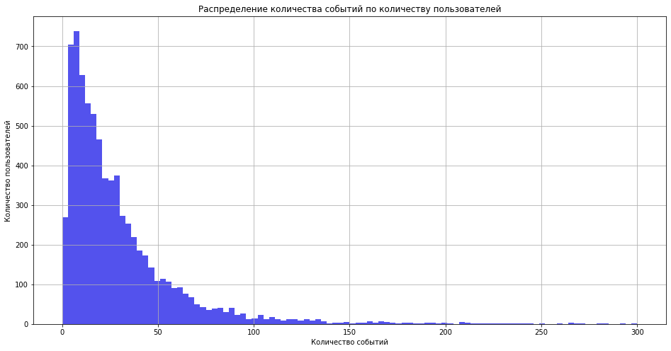

```python
plt.title('Распределение количества событий по количеству пользователей')
plt.xlabel('Количество событий')
plt.ylabel('Количество пользователей')
data['device_id'].value_counts().hist(bins=100, range=(0,300), figsize=(16,8), color = '#5352ed')
plt.show();
```

```python
mode_event_per_id = data['device_id'].value_counts().mode()[0]
mode_event_per_id
```

```
5
```

```python
mean_event_per_id = all_event/all_id
mean_event_per_id
```

```
32.27559263673685
```

#### *Проверим, данные за какой период доступны*

```python
firts_date = data['event_date'].min()
last_date = data['event_date'].max()
```

```python
firts_date
```

```
Timestamp('2019-07-25 04:43:36')
```

```python
last_date
```

```
Timestamp('2019-08-07 21:15:17')
```

```python
time_to_event = data.groupby('event_day')['event_date'].count()
```

```python
fig = go.Figure()
fig.add_trace(go.Bar(x=time_to_event.index, y=time_to_event.values,
            text=time_to_event.values.round(2),
            textposition='outside'))
fig.update_layout(
    title='График логов по дням',
    xaxis_title='Дни',
    yaxis_title='Количество событий',
    title_x = 0.5,
    margin=dict(l=50, r=50, t=130, b=50))
fig.update_xaxes(nticks=20)
fig.show();
```

[interactive chart not shown]

Полноценные данные есть только за август, очистим данные от логов июля:

```python
clean_data = data.query('event_date > "2019-08-01"')
```

```python
clean_event = clean_data['event_name'].count()
clean_event
```

```
240887
```

```python
clean_id = clean_data['device_id'].nunique()
clean_id
```

```
7534
```

```python
print('Потеряли: {} событий, {}%'
      .format(all_event - clean_event, round(100- clean_event/all_event*100, 2)))
```

```
Потеряли: 2826 событий, 1.16%
```

```python
print('Потеряли: {} пользователей, {}%'
      .format(all_id - clean_id, round(100- clean_id/all_id*100, 2)))
```

```
Потеряли: 17 пользователей, 0.23%
```

#### *Убедимся, что есть пользователи из всех трёх экспериментальных групп:*

```python
clean_data.groupby('exp_group').agg({'device_id':'nunique'})
```

| exp_group | device_id |
| --- | --- |
| 246 | 2484 |
| 247 | 2513 |
| 248 | 2537 |

### Вывод:

В массиве данных были неполные данные за июль, анализировать будем только данные за август (240887 событий от 7534 пользователей). Количество пользователей в группах распределено равномерно.

### Шаг 3. Изучение воронки событий

#### *Изучим, какие события есть в логах и как часто они встречаются*

```python
event_type_count = clean_data['event_name'].value_counts().reset_index()
event_type_count.columns = ['event_name','event_number']
```

```python
event_type_count
```

|  | event_name | event_number |
| --- | --- | --- |
| 0 | MainScreenAppear | 117328 |
| 1 | OffersScreenAppear | 46333 |
| 2 | CartScreenAppear | 42303 |
| 3 | PaymentScreenSuccessful | 33918 |
| 4 | Tutorial | 1005 |

#### *Посчитаем долю пользователей, которые хоть раз совершали событие:*

```python
event_users = clean_data.groupby('event_name').agg({'device_id':'nunique'}).sort_values(by='device_id', ascending=False).reset_index()
```

```python
event_users['%_of_id'] = event_users['device_id'] / clean_id * 100
```

```python
event_users
```

|  | event_name | device_id | %_of_id |
| --- | --- | --- | --- |
| 0 | MainScreenAppear | 7419 | 98.473586 |
| 1 | OffersScreenAppear | 4593 | 60.963632 |
| 2 | CartScreenAppear | 3734 | 49.561986 |
| 3 | PaymentScreenSuccessful | 3539 | 46.973719 |
| 4 | Tutorial | 840 | 11.149456 |

#### *Выстроим события последовательно:*

Логика действий пользователя такая: он заходит на главный экран, смотрит или не смотрит обучающие картинки/видео, затем переходит к товарам. Далее начинается оформление и просмотр корзины, а после этого видит экран успешной оплаты.

Обучающие картинки/видео — совсем не обязательный этап, его можно скипнуть, поэтому в исследовании тоже не будет его учитывать.

```python
event_type_count_without_tutorial = event_type_count[:4]
```

```python
event_type_count_without_tutorial
```

|  | event_name | event_number |
| --- | --- | --- |
| 0 | MainScreenAppear | 117328 |
| 1 | OffersScreenAppear | 46333 |
| 2 | CartScreenAppear | 42303 |
| 3 | PaymentScreenSuccessful | 33918 |

```python
fig = go.Figure()
fig.add_trace(go.Funnel(y=event_type_count_without_tutorial['event_name'], x=event_type_count_without_tutorial['event_number']))
fig.update_layout(
    title='График воронки действий пользователей',
    title_x = 0.5,
    margin=dict(l=50, r=50, t=130, b=50))
fig.show()
```

[interactive chart not shown]

#### *Посчитаем, какая доля пользователей проходит на следующий шаг воронки (от числа пользователей на предыдущем):*

```python
event_users_without_tutorial = event_users[:4]
```

```python
event_users_without_tutorial
```

|  | event_name | device_id | %_of_id |
| --- | --- | --- | --- |
| 0 | MainScreenAppear | 7419 | 98.473586 |
| 1 | OffersScreenAppear | 4593 | 60.963632 |
| 2 | CartScreenAppear | 3734 | 49.561986 |
| 3 | PaymentScreenSuccessful | 3539 | 46.973719 |

```python
event_users_without_tutorial['%_of_initial'] = (event_users_without_tutorial['device_id']
                                              /event_users_without_tutorial['device_id'][0]) *100
```

```python
event_users_without_tutorial.loc[0, '%_of_previous'] = 100
```

```python
for i in range(1,4):
    event_users_without_tutorial['%_of_previous'][i] = (event_users_without_tutorial['device_id'][i]/
                                                        event_users_without_tutorial['device_id'][i-1]) *100
```

```python
event_users_without_tutorial
```

|  | event_name | device_id | %_of_id | %_of_initial | %_of_previous |
| --- | --- | --- | --- | --- | --- |
| 0 | MainScreenAppear | 7419 | 98.473586 | 100.000000 | 100.000000 |
| 1 | OffersScreenAppear | 4593 | 60.963632 | 61.908613 | 61.908613 |
| 2 | CartScreenAppear | 3734 | 49.561986 | 50.330233 | 81.297627 |
| 3 | PaymentScreenSuccessful | 3539 | 46.973719 | 47.701847 | 94.777718 |

```python
fig = go.Figure()
fig.add_trace(go.Funnel(y=event_users_without_tutorial['event_name'], x=event_users_without_tutorial['device_id']))
fig.update_layout(
    title='График воронки пользователей',
    title_x = 0.5,
    margin=dict(l=50, r=50, t=130, b=50))
fig.show()
```

[interactive chart not shown]

Проверим, сколько пользователей прошли все этапы в хронологическом порядке:

```python
users = clean_data.pivot_table(
    index='device_id',
    columns='event_name',
    values='event_date',
    aggfunc='min')
```

```python
users
```

| event_name device_id | CartScreenAppear | MainScreenAppear | OffersScreenAppear | PaymentScreenSuccessful | Tutorial |
| --- | --- | --- | --- | --- | --- |
| 6888746892508752 | NaT | 2019-08-06 14:06:34 | NaT | NaT | NaT |
| 6909561520679493 | 2019-08-06 18:52:58 | 2019-08-06 18:52:54 | 2019-08-06 18:53:04 | 2019-08-06 18:52:58 | NaT |
| 6922444491712477 | 2019-08-04 14:19:40 | 2019-08-04 14:19:33 | 2019-08-04 14:19:46 | 2019-08-04 14:19:40 | NaT |
| 7435777799948366 | NaT | 2019-08-05 08:06:34 | NaT | NaT | NaT |
| 7702139951469979 | 2019-08-02 14:28:45 | 2019-08-01 04:29:54 | 2019-08-01 04:29:56 | 2019-08-02 14:28:45 | NaT |
| ... | ... | ... | ... | ... | ... |
| 9217594193087726423 | 2019-08-02 09:00:58 | NaT | 2019-08-02 09:01:08 | 2019-08-02 09:00:57 | NaT |
| 9219463515465815368 | 2019-08-06 16:49:40 | 2019-08-05 05:26:26 | 2019-08-06 16:48:57 | 2019-08-06 16:52:16 | NaT |
| 9220879493065341500 | 2019-08-02 17:59:16 | 2019-08-02 17:58:48 | 2019-08-02 17:59:00 | NaT | NaT |
| 9221926045299980007 | NaT | 2019-08-01 17:30:27 | NaT | NaT | NaT |
| 9222603179720523844 | NaT | 2019-08-01 06:52:13 | NaT | NaT | NaT |

7534 rows × 5 columns

```python
step_1 = ~users['MainScreenAppear'].isna()
step_2 = step_1 & (users['OffersScreenAppear'] > users['MainScreenAppear'])
step_3 = step_2 & (users['CartScreenAppear'] > users['OffersScreenAppear'])
step_4 = step_3 & (users['PaymentScreenSuccessful'] > users['CartScreenAppear'])
```

```python
n_pageview = users[step_1].shape[0]
n_offers = users[step_2].shape[0]
n_cart = users[step_3].shape[0]
n_payment = users[step_4].shape[0]
```

```python
event_users_without_tutorial['every_way'] = [n_pageview, n_offers, n_cart, n_payment]
```

```python
event_users_without_tutorial
```

|  | event_name | device_id | %_of_id | %_of_initial | %_of_previous | every_way |
| --- | --- | --- | --- | --- | --- | --- |
| 0 | MainScreenAppear | 7419 | 98.473586 | 100.000000 | 100.000000 | 7419 |
| 1 | OffersScreenAppear | 4593 | 60.963632 | 61.908613 | 61.908613 | 4201 |
| 2 | CartScreenAppear | 3734 | 49.561986 | 50.330233 | 81.297627 | 1767 |
| 3 | PaymentScreenSuccessful | 3539 | 46.973719 | 47.701847 | 94.777718 | 454 |

```python
fig = go.Figure()
fig.add_trace(go.Funnel(y=event_users_without_tutorial['event_name'], x=event_users_without_tutorial['every_way']))
fig.update_layout(
    title='График воронки пользователей (тех, кто посетил каждый шаг в верной последовательности)',
    title_x = 0.5,
    margin=dict(l=50, r=50, t=130, b=50))
fig.show()
```

[interactive chart not shown]

6.1% проходят через все этапы последовательно и 47.7% попадают от первого события к оплате (возможно, пропускают какой-то этап)

### Вывод

Пользователи часто просматривают главный экран, но к процессу выбора товаров доходят не все. Только 47.7% пользователей доходят от первого события до окна успешной оплаты.

Всего 454 пользователя прошли все этапы в хронологическом порядке, вероятно, большая часть пользователей не переходят к просмотру корзины, а выбирают быстрое оформление заказа.

### Шаг 4. Изучим результаты эксперимента

```python
users_per_group = clean_data.groupby('exp_group').agg({'device_id':'nunique'}).reset_index()
users_per_group.columns = ['exp_group', 'users']
```

```python
users_per_group
```

|  | exp_group | users |
| --- | --- | --- |
| 0 | 246 | 2484 |
| 1 | 247 | 2513 |
| 2 | 248 | 2537 |

#### *Проверим, находят ли статистические критерии разницу между выборками 246 и 247:*

```python
data_table = clean_data.pivot_table(index='exp_group', columns='event_name', values='device_id', aggfunc='nunique').reset_index()
```

```python
data_table
```

| event_name | exp_group | CartScreenAppear | MainScreenAppear | OffersScreenAppear | PaymentScreenSuccessful | Tutorial |
| --- | --- | --- | --- | --- | --- | --- |
| 0 | 246 | 1266 | 2450 | 1542 | 1200 | 278 |
| 1 | 247 | 1238 | 2476 | 1520 | 1158 | 283 |
| 2 | 248 | 1230 | 2493 | 1531 | 1181 | 279 |

```python
data_table = data_table.merge(users_per_group)
```

```python
unionAA = data_table.loc[0] + data_table.loc[1]
unionAA.name = 3
unionAA['exp_group'] = '246+247'
```

```python
data_table = data_table.append([unionAA])
```

```python
data_table
```

|  | exp_group | CartScreenAppear | MainScreenAppear | OffersScreenAppear | PaymentScreenSuccessful | Tutorial | users |
| --- | --- | --- | --- | --- | --- | --- | --- |
| 0 | 246 | 1266 | 2450 | 1542 | 1200 | 278 | 2484 |
| 1 | 247 | 1238 | 2476 | 1520 | 1158 | 283 | 2513 |
| 2 | 248 | 1230 | 2493 | 1531 | 1181 | 279 | 2537 |
| 3 | 246+247 | 2504 | 4926 | 3062 | 2358 | 561 | 4997 |

Определим нулевую и альтернативную гипотезы.

*Нулевая гипотеза*: между группами нет статистически значимых различий.

*Альтернативная гипотеза*: между группами есть статистически значимые различия.

```python
alpha = .01
```

```python
def stat_group (value_1, value_2, total_1, total_2):
    p1 = value_1/total_1
    p2 = value_2/total_2
    p_combined = (value_1 + value_2) / (total_1 + total_2)
    difference = p1 - p2
    z_value = difference / mth.sqrt(p_combined * (1 - p_combined) * (1/total_1 + 1/total_2))
    distr = st.norm(0, 1)
    p_value = (1 - distr.cdf(abs(z_value))) * 2
    print('p-значение: ', p_value)
    if (p_value < alpha):
        print("Отвергаем нулевую гипотезу: между долями есть значимая разница")
    else:
        print("Не получилось отвергнуть нулевую гипотезу, нет оснований считать доли разными")
```

```python
dict = ['MainScreenAppear', 'OffersScreenAppear', 'CartScreenAppear', 'PaymentScreenSuccessful']
```

```python
def test(group_1, group_2):
    for i in range(4):
        stat_group(data_table[dict[i]][group_1],
                   data_table[dict[i]][group_2],
                   data_table['users'][group_1],
                   data_table['users'][group_2])
```

```python
test(0, 1)
```

```
p-значение:  0.7570597232046099
Не получилось отвергнуть нулевую гипотезу, нет оснований считать доли разными
p-значение:  0.2480954578522181
Не получилось отвергнуть нулевую гипотезу, нет оснований считать доли разными
p-значение:  0.22883372237997213
Не получилось отвергнуть нулевую гипотезу, нет оснований считать доли разными
p-значение:  0.11456679313141849
Не получилось отвергнуть нулевую гипотезу, нет оснований считать доли разными
```

Статистически значимых различий между группами A(246) и A(247) не обнаружено. Это значит, что тест проведён корректно и можно анализировать результаты A/B теста.

#### *Сравним результаты с каждой из контрольных групп в отдельности по каждому событию:*

Сравниваем A(246) с B:

```python
test(0, 2)
```

```
p-значение:  0.2949721933554552
Не получилось отвергнуть нулевую гипотезу, нет оснований считать доли разными
p-значение:  0.20836205402738917
Не получилось отвергнуть нулевую гипотезу, нет оснований считать доли разными
p-значение:  0.07842923237520116
Не получилось отвергнуть нулевую гипотезу, нет оснований считать доли разными
p-значение:  0.2122553275697796
Не получилось отвергнуть нулевую гипотезу, нет оснований считать доли разными
```

Сравниваем A(247) с B:

```python
test(1, 2)
```

```
p-значение:  0.4587053616621515
Не получилось отвергнуть нулевую гипотезу, нет оснований считать доли разными
p-значение:  0.9197817830592261
Не получилось отвергнуть нулевую гипотезу, нет оснований считать доли разными
p-значение:  0.5786197879539783
Не получилось отвергнуть нулевую гипотезу, нет оснований считать доли разными
p-значение:  0.7373415053803964
Не получилось отвергнуть нулевую гипотезу, нет оснований считать доли разными
```

Сравниваем AA(246+247) с B:

```python
test(3, 2)
```

```
p-значение:  0.29424526837179577
Не получилось отвергнуть нулевую гипотезу, нет оснований считать доли разными
p-значение:  0.43425549655188256
Не получилось отвергнуть нулевую гипотезу, нет оснований считать доли разными
p-значение:  0.18175875284404386
Не получилось отвергнуть нулевую гипотезу, нет оснований считать доли разными
p-значение:  0.6004294282308704
Не получилось отвергнуть нулевую гипотезу, нет оснований считать доли разными
```

#### *Обоснование уровня значимости*

Выбрали уровень значимости в 0.01. В исследовании проверили 4 проверки для A/A теста и ещё 12 для A/B тестов. Чтобы снизить групповую вероятность ошибки первого рода, можно использовать метод Шидака (он повысит мощность теста) или Бенферони.

Ни в одной из проверок не было обнаружено статистически значимых различий, поэтому не будем менять значение alpha, но проверим, какое оно бы получилось с использованием метода Шидака:

```python
[1 - (1 - alpha)**(1/m) for m in range(1, 17)]
```

```
[0.010000000000000009,
 0.005012562893380035,
 0.003344506587403595,
 0.002509430066318874,
 0.002008048338574153,
 0.0016736538523104416,
 0.0014347320512516637,
 0.0012555031772735203,
 0.0011160807018574248,
 0.0010045287082499632,
 0.0009132496292652004,
 0.0008371773591205889,
 0.0007728039910219753,
 0.0007176235173821377,
 0.0006697979753554906,
 0.0006279487484520674]
```

### Вывод

Статистически значимых различий между группами A (246 и 247) не нашли — это значит, что пользователи распределены в группах случайным образом.

Также статистических различий не нашли и между этими группами и группой B (с измененным шрифтом), что означает, что шрифт не влияет на процесс покупки, поэтому можно смело менять шрифт во всём приложении, если это необходимо. Пользователей такая перемена не отпугивает :)